# Approximate Bayesian computation

# The model we fit

We keep the SEIT4L model from the particle filter and particle MCMC sessions, simulated stochastically. Run it twice at the same parameters and you get two different epidemics, so there is no single curve to hold against the data.

The particle MCMC session already fitted this model, and fitted it better than this session will. It estimated all six parameters where we estimate three, and it reached a tighter posterior from fewer simulations. On this outbreak the particle filter is the better tool, and we use the same model anyway so that you can hold ABC against an answer you already trust.

ABC earns its place where the particle filter cannot run at all. The filter weights each particle by an observation density $p(y_t \mid x_t)$, so you have to be able to write one down. It also stops the simulator at every observation, copies the state and restarts from it, so you have to be able to checkpoint the simulator. A compiled model you cannot open, someone else’s executable, or a reporting process nobody can put a density on: any of these rules the filter out and leaves ABC standing. Neither is true here, which is exactly why this is a good place to learn ABC and a poor argument for using it.

Three parameters are estimated, $R_0$, $D_\mathrm{inf}$ and $\rho$, and the rest are fixed at the values the earlier sessions used. Every free parameter has to land inside the acceptance window at the same time, so the acceptance rate falls away sharply as the number of free parameters grows.

```julia
## Fixed at the values used in the SEITL session
const D_LAT = 2.0
const ALPHA = 0.5
const D_IMM = 13.0

## The island as the ship lands, at the start of day 1: three of the five
## returning islanders are past their infectious period and start in T1, the two
## who fell ill on landing start in I. N = 284
init_test = [279.0, 0.0, 2.0, 3.0, 0.0, 0.0, 0.0, 0.0]
n_obs = length(flu_tdc.obs)

## One stochastic SEIT4L run, thinned to reported cases, one value per day
function simulate_seit4l_obs(R_0, D_inf, ρ)
    θ = Dict(:R_0 => R_0, :D_lat => D_LAT, :D_inf => D_inf,
             :α => ALPHA, :D_imm => D_IMM)
    state = copy(init_test)
    inc = [gillespie_step_seit4l!(state, θ, 1.0) for _ in 1:n_obs]
    return [rand(Poisson(max(ρ * x, 1e-10))) for x in inc]
end
```

```
simulate_seit4l_obs (generic function with 1 method)
```

**Plotting code**

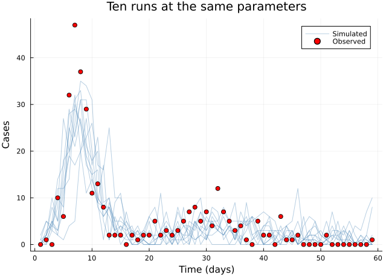

```julia
p_runs = plot(xlabel = "Time (days)", ylabel = "Cases",
              title = "Ten runs at the same parameters")

for i in 1:10
    plot!(p_runs, flu_tdc.time, simulate_seit4l_obs(7.0, 2.5, 0.65),
          color = :steelblue, alpha = 0.4, label = i == 1 ? "Simulated" : "")
end

scatter!(p_runs, flu_tdc.time, flu_tdc.obs, color = :red, markersize = 4,
         label = "Observed")
```

Ten runs, one parameter set, ten different epidemics. That spread sets the standard every distance in this session has to meet, because those ten runs are all equally plausible under those parameters. It prevents even a good parameter set from landing close to the data reliably, and the ABC-MCMC section below shows what that does to a sampler.

**NoteThe likelihood fit we compare against**

At the end we hold the ABC posterior against a likelihood-based one. For this model that is the particle MCMC fit from the previous session, whose chain is precomputed in `data/`. The Poisson observation model is still in use, inside the filter, weighting particles one observation at a time. What has no closed form is $p(y \mid \theta)$ itself, because forming it means summing over every path the epidemic could have taken. The particle filter estimates that sum. ABC never forms it, and compares simulated output with the data through a distance.

```julia
pmcmc_chain = CSV.read(datadir("pmcmc_seit4l_chain.csv"), DataFrame)
first(pmcmc_chain, 3)
```

3×12 DataFrame

| Row | R_0 Float64 | D_lat Float64 | D_inf Float64 | α Float64 | D_imm Float64 | ρ Float64 | logα Float64 | η Float64 | accepted Float64 | logprior Float64 | loglikelihood Float64 | logjoint Float64 |
| --- | --- | --- | --- | --- | --- | --- | --- | --- | --- | --- | --- | --- |
| 1 | 5.67591 | 1.44572 | 1.74464 | 0.449021 | 11.3783 | 0.683158 | 0.0 | 0.00151572 | 1.0 | -7.58173 | -116.699 | -124.281 |
| 2 | 6.60763 | 1.20272 | 2.37858 | 0.518606 | 8.79137 | 0.606997 | -7.63637 | 0.00151572 | 0.0 | -8.34992 | -118.181 | -126.531 |
| 3 | 6.62027 | 0.98478 | 3.15098 | 0.399522 | 11.5573 | 0.658545 | -3.50687 | 0.00151572 | 0.0 | -8.47887 | -118.081 | -126.56 |

# Approximate Bayesian computation

## ABC: Making the distance explicit

A parametric likelihood settles three questions for you, quietly, as a consequence of the distribution you picked. ABC puts the same three in front of you and makes you answer them yourself:

1. *Summary statistics*: which features of the data matter?
2. *Distance*: how do we measure similarity?
3. *Threshold*: how close is close enough?

That is the sense in which ABC makes the distance explicit. The choices were always there.

Here is a simple ABC rejection sampler from scratch:

```julia
"""
Simple ABC rejection sampler.
Samples from prior, simulates data, accepts if distance < threshold.
"""
function abc_rejection(prior_sampler, simulator, distance_fn, observed_data,
                      threshold, n_samples)
    samples = []
    n_attempts = 0
    max_attempts = n_samples * 1000  # Give up after many attempts

    while length(samples) < n_samples && n_attempts < max_attempts
        n_attempts += 1

        # Sample from prior
        θ = prior_sampler()

        # Simulate data
        simulated_data = simulator(θ)

        # Compute distance
        d = distance_fn(simulated_data, observed_data)

        # Accept if close enough
        if d < threshold
            push!(samples, θ)
        end
    end

    acceptance_rate = length(samples) / n_attempts
    println("Acceptance rate: $(round(acceptance_rate * 100, digits=2))%")
    println("Attempts needed: $n_attempts")

    ## The attempt count is returned as well as printed, so the comparison at the
    ## end of the session can put it beside the ABC-SMC simulation count
    return samples, n_attempts
end
```

```
Main.Notebook.abc_rejection
```

The components are:

```julia
# Prior
## The same priors the particle MCMC session used for these three parameters.
## Particle MCMC estimated three additional parameters that ABC fixes above, so
## their posterior comparison is not a pure comparison of inference methods.
## Defined once here and read by all three samplers below: rejection draws from
## them, ABC-MCMC uses the density in its accept step, and ABC-SMC uses it in the
## importance weights
const PRIORS = [truncated(Normal(3.0, 2.0), lower = 1.0),  ## R_0
                truncated(Normal(3.0, 2.0), lower = 0.5),  ## D_inf
                Beta(2, 2)]                                ## ρ

sample_from_prior() = rand.(PRIORS)

## -Inf outside the support, so this doubles as a bounds check
log_prior(θ) = sum(logpdf(PRIORS[d], θ[d]) for d in eachindex(θ))

prior_pdf(θ) = exp(log_prior(θ))

in_prior(θ) = isfinite(log_prior(θ))

# Simulator
simulate_abc(params) = simulate_seit4l_obs(params...)

# Distance functions
distance_L1(sim, obs) = sum(abs.(sim .- obs))

## A single summary statistic rather than the whole series: the total number of
## cases over the outbreak. Cheap, and much easier to land inside a window.
distance_total(sim, obs) = abs(sum(sim) - sum(obs))

function distance_L2(sim, obs)
    return sqrt(sum((sim .- obs).^2))
end

function distance_weighted(sim, obs)
    # An observation-scaled absolute distance: closer to relative error
    weights = 1.0 ./ (obs .+ 1.0)
    return sum(weights .* abs.(sim .- obs))
end

# Observed data
observed_data = flu_tdc.obs
```

```
59-element Vector{Int64}:
  0
  1
  0
 10
  6
 32
 47
 37
 29
 11
  ⋮
  2
  0
  0
  0
  0
  0
  0
  0
  1
```

**NoteUnderstanding the distance functions**

The three distance functions have different properties:

- **L1 (Manhattan)**: `sum(|sim - obs|)` - Sums absolute deviations. Robust to outliers because large errors contribute linearly. A mismatch of 20 cases counts twice as much as a mismatch of 10.
- **L2 (Euclidean)**: `sqrt(sum((sim - obs)²))` - Root of squared deviations. The *squared contribution* of a mismatch of 20 is four times that of 10 (400 versus 100). If it is the only mismatch, the final Euclidean distance is twice as large because of the square root.
- **Weighted**: `sum(w × |sim - obs|)` where `w = 1/(obs + 1)` - Weights inversely by observation size, so a mismatch of 5 when obs=2 is penalised more than when obs=50. This is an observation-scaled absolute error, useful when you care about relative fit; it is not a Poisson discrepancy.

**When to use each:**

- L1: Good default. Robust to occasional large mismatches.
- L2: When large deviations are particularly bad (e.g., outbreak peaks).
- Weighted: When fit quality should be relative to the observed scale.

This is the same comparison as Poisson against negative binomial, which you met yesterday. A negative log-likelihood is a distance, and each observation model fixes how steeply that distance grows with one day’s discrepancy. Take an expected count of 5 and double a discrepancy from 10 cases to 20: L1 doubles, the squared error inside L2 quadruples, the Poisson negative log-likelihood multiplies by 3, and a negative binomial with dispersion 2 multiplies by 2.2. Poisson sits between the two distances, and the negative binomial lands close to L1. Near a good fit the Poisson term is about $d^2 / 2\lambda$, which is the weighted distance above with squares in place of absolute values.

So choosing a distance and choosing an observation model are one decision, made twice: how steeply should a surprising observation count against you.

Run ABC with L1 distance:

**WarningChoosing the threshold**

ABC rejection sampling is sensitive to the threshold choice:

- **Too strict** (e.g., 100): no acceptance was seen at this level in calibration runs, so it is likely to exhaust the attempt budget
- **Too loose** (e.g., 1000): Fast, but approximate posterior is close to the prior
- **In between** (e.g., 200-400): Runs quickly, but at the loose end of this band the posterior still carries a good deal of the prior

We start with a relaxed threshold (230) here. The run below accepts around 7% of what it proposes. By the guidance later in this session that is loose, and the posterior still holds a good deal of the prior. The exercise that follows asks you to tighten it.

**If you get 0 samples**: Increase the threshold (try 280, then 330). The sampler may be struggling to find parameter combinations that produce simulations close to the data. This can happen due to random variation - ABC is inherently stochastic.

```julia
# Start with a relaxed threshold to get some samples
threshold = 230.0  # about 7% acceptance from the prior

println("Running ABC rejection sampler...")
abc_samples, abc_attempts = abc_rejection(
    sample_from_prior,
    simulate_abc,
    distance_L1,
    observed_data,
    threshold,
    200  # Target number of samples
)

println("\nObtained $(length(abc_samples)) samples")
```

```
Running ABC rejection sampler...
Acceptance rate: 7.04%
Attempts needed: 2839

Obtained 200 samples
```

**TipExercise: Find a workable threshold**

The threshold above (230) was chosen for you. Find out what it is doing by changing it.

1. Re-run the sampler with a stricter threshold, say 190. How many simulations does it get through, and how long does it take?
2. Re-run with a loose one, say 800. How wide is the resulting posterior for $R_0$ compared with the run at 230?
3. What are you giving up on each side, and how would you decide on a value if you had no answer to compare against?

**TipSolution**

Tightening the threshold narrows the posterior but the acceptance rate collapses, so you wait much longer for the same number of samples: about 6% of prior draws are accepted at 230, roughly 1% at 190 and 0.2% at 165, so each step takes about five times as many simulations as the last. There is a practical floor as well. Over twenty thousand prior draws the closest any simulation came to these data was a distance of about 130, so acceptance below that was not observed and would be computationally inaccessible in this practical. This is empirical, not a hard mathematical bound: the count simulator can in principle produce a closer series. Some of the practical floor is the model and some of it is the noise: even at the particle MCMC parameters, two runs differ from the data by anywhere between 155 and 420.

Loosening it accepts almost everything, so the sampler is fast but the posterior drifts back towards the prior: you are no longer conditioning on the data very much.

There is no way to pick $\epsilon$ from first principles. In practice you lower it until either the posterior stops changing or the acceptance rate becomes unaffordable, whichever comes first. This is exactly the weakness that ABC-SMC in the next section is designed to address, by walking the threshold down automatically.

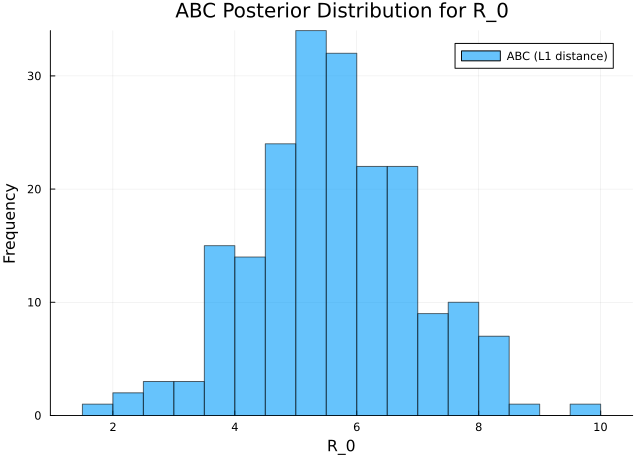

```julia
# Extract parameters
if length(abc_samples) > 0
    abc_df = DataFrame(
        R_0 = [s[1] for s in abc_samples],
        D_inf = [s[2] for s in abc_samples],
        ρ = [s[3] for s in abc_samples]
    )

    # Plot ABC results
    histogram(abc_df.R_0, bins=30, alpha=0.6,
              label="ABC (L1 distance)",
              xlabel="R_0", ylabel="Frequency",
              title="ABC Posterior Distribution for R_0")
else
    println("No samples accepted - threshold too strict!")
end
```

## A summary statistic in place of the series

`distance_total` throws away everything except the total number of cases, one number against fifty-nine. It is also on a different scale from `distance_L1`, so the two acceptance rates below can only be compared once you fix a threshold for each, and the thresholds here were picked to make them roughly comparable. The posteriors are what the comparison rests on.

**TipExercise: What does the summary give up?**

The cell below runs `abc_rejection` with `distance_total` at a threshold of 25 and again at 12, and prints the $R_0$ posterior beside the `distance_L1` one and the particle MCMC one. Predict the three answers before you run it.

1. How does the acceptance rate compare with `distance_L1`?
2. Does the $R_0$ posterior agree with the particle MCMC answer, in its centre and in its width?
3. Tightening the threshold from 25 to 12 takes more simulations. What do you get for them?

```julia
function summarise_R_0(name, samples, attempts)
    R_0 = [θ[1] for θ in samples]
    println(rpad(name, 22),
            " acceptance ", lpad(round(100 * length(samples) / attempts, digits = 2), 6),
            "%   R_0 mean ", lpad(round(mean(R_0), digits = 2), 5),
            "  90% interval ", lpad(round(quantile(R_0, 0.05), digits = 2), 5),
            " to ", lpad(round(quantile(R_0, 0.95), digits = 2), 5))
end

for ε in (25.0, 12.0)
    samples, attempts = abc_rejection(sample_from_prior, simulate_abc,
                                      distance_total, observed_data, ε, 200)
    summarise_R_0("total, ε = $ε", samples, attempts)
end

summarise_R_0("L1, ε = $threshold", abc_samples, abc_attempts)

println(rpad("particle MCMC", 22), "                    R_0 mean ",
        lpad(round(mean(pmcmc_chain.R_0), digits = 2), 5),
        "  90% interval ", lpad(round(quantile(pmcmc_chain.R_0, 0.05), digits = 2), 5),
        " to ", lpad(round(quantile(pmcmc_chain.R_0, 0.95), digits = 2), 5))
```

```
Acceptance rate: 6.64%
Attempts needed: 3012
total, ε = 25.0        acceptance   6.64%   R_0 mean  4.65  90% interval  2.69 to  7.09
Acceptance rate: 3.2%
Attempts needed: 6250
total, ε = 12.0        acceptance    3.2%   R_0 mean  4.74  90% interval   2.7 to  7.03
L1, ε = 230.0          acceptance   7.04%   R_0 mean   5.6  90% interval   3.5 to  7.75
particle MCMC                             R_0 mean  6.36  90% interval  4.57 to  8.39
```

**TipWhat to look for**

The acceptance rates are close, around 7% for L1 at 230 and around 7% for the total at 25, because the thresholds were chosen to make them so. The posteriors are not close.

$R_0$ centres near 4.7 on the total, against 5.6 on L1 and 6.4 from particle MCMC. The interesting part is where that difference does *not* show up. The 90% intervals are about equally wide, roughly 4.4 wide on the total and 4.3 on L1, so throwing away the timing has moved the posterior down instead of spreading it out. Both ABC intervals still cover the particle MCMC mean; the total’s sits lowest.

Many different epidemics produce 312 cases: a fast one that burns out, a slow one that grinds on, a small $R_0$ with a high reporting rate. The total cannot tell them apart, so it leaves $R_0$ and $\rho$ free to trade against each other, and the posterior settles lower down that trade than the full series allows.

Tightening from 25 to 12 halves the acceptance rate and moves the posterior almost not at all: the mean shifts by about 0.1 and the interval is unchanged. A tighter threshold on `distance_L1` does pull the answer towards the particle MCMC one.

This is the difference between the two approximations ABC makes. The threshold is one, and more simulations get you out of it. The summary is the other, and you cannot: once the total is all you compare, no threshold recovers the timing information you discarded. A summary that is not sufficient puts a floor under the error, and $\epsilon \to 0$ does not lift it.

**NoteABC-MCMC, and why this session does not use it**

You have built Metropolis-Hastings twice in this course: once by hand in the MCMC session, and once with a particle filter supplying the likelihood in the particle MCMC session. ABC gives you a third version of the same loop. Propose a step, simulate once from the proposed parameters, and accept if that simulation lands within ε of the data. That is ABC-MCMC, introduced by [Marjoram et al. (2003)](https://doi.org/10.1073/pnas.0306899100). The accept step is the Metropolis-Hastings one with the likelihood ratio deleted and the distance test put in its place; the prior ratio stays, and the priors here are not uniform, so nothing cancels.

```julia
"""
ABC-MCMC. Propose, test the prior ratio, then simulate once and accept if the
simulation lands within `threshold` of the data. Returns the chain and the
acceptance rate.
"""
function abc_mcmc(θ_start, simulator, distance_fn, observed_data, threshold,
                  n_iterations; proposal_sd = [0.4, 0.3, 0.05])
    chain = Vector{Vector{Float64}}(undef, n_iterations)
    θ = copy(θ_start)
    lp = log_prior(θ)
    n_accepted = 0

    for i in 1:n_iterations
        θ_proposed = θ .+ randn(length(θ)) .* proposal_sd
        lp_proposed = log_prior(θ_proposed)

        ## The prior ratio is checked first because it is free, and a proposal
        ## that fails it needs no simulation. The proposal is symmetric, so it
        ## contributes nothing to the ratio
        if isfinite(lp_proposed) && log(rand()) < lp_proposed - lp &&
           distance_fn(simulator(θ_proposed), observed_data) < threshold
            θ, lp = θ_proposed, lp_proposed
            n_accepted += 1
        end

        chain[i] = copy(θ) ## the state after the step, whether or not it moved
    end

    return chain, n_accepted / n_iterations
end
```

```
Main.Notebook.abc_mcmc
```

## ABC-SMC: Sequential Monte Carlo ABC

Both samplers so far run out of road well before the threshold is tight. Rejection sampling wastes almost everything it draws, because it searches from the prior every time and never learns where the good parameters were. ABC-MCMC does learn that, and seizes up as a result: at a tight threshold it accepts only lucky realisations and then cannot leave them. ABC-SMC (Sequential Monte Carlo ABC) gets round both by tightening the acceptance threshold across a sequence of generations, reusing the particles that survived the previous one.

The key idea, introduced by [Toni et al. (2009)](https://doi.org/10.1098/rsif.2008.0172), is:

1. *Start permissive*: Begin with a loose threshold that accepts many samples
2. *Gradually tighten*: Reduce the threshold across generations
3. *Reuse good samples*: after the first generation, draw a parent from the survivors in proportion to its weight and perturb it, leaving the prior behind

The aim is to reach a threshold out of reach of rejection sampling, by refining particles that are already close. How much that saves depends entirely on the problem, the schedule and the kernel, so treat quoted speedup factors with suspicion until you have counted your own.

**NoteImplementation: ABC-SMC**

This is a simplified ABC-SMC for pedagogical purposes. It does compute the importance weights, which is what makes the sample valid, but production implementations (like ApproxBayes.jl or GpABC.jl) add adaptive thresholds and better perturbation kernels.

A perturbation landing outside the prior sends the loop back to its start, which draws a *new parent* as well as a new perturbation, so the proposal is the whole mixture restricted to the prior’s support. The constant that restriction introduces is the same for every particle, so it cancels when the weights are normalised, and the weights computed here are exact. Had the redraw kept the same parent and only re-perturbed, it would not cancel, and children of near-boundary particles would come out over-weighted.

**Note on `Threads.@threads`**: The code below uses `Threads.@threads` to parallelise the particle loop. The macro distributes iterations across available CPU threads, so each particle can be simulated concurrently. For this to have any effect, Julia must be started with multiple threads (e.g., `julia -t auto`). See the threading note in MCMC diagnostics for setup instructions. Without multiple threads, the loop runs sequentially (slower but still correct).

```julia
"Standard deviation of the perturbation kernel applied to a particle."
kernel_sd(θ) = 0.1 .* abs.(θ)

"Density of the perturbation kernel that moves `θ_from` to `θ_to`."
function kernel_pdf(θ_to, θ_from)
    sds = kernel_sd(θ_from)
    return prod(pdf(Normal(θ_from[d], sds[d]), θ_to[d]) for d in eachindex(θ_to))
end

"""
Simple ABC-SMC implementation.
Uses a sequence of decreasing thresholds, perturbing the particles that survived
the previous one. Returns the particles, their importance weights, the number of
simulations each generation cost, and the effective sample size of each
generation's weights.
"""
function abc_smc(prior_sampler, in_prior, simulator, distance_fn, observed_data,
                thresholds, n_particles; max_simulations_per_generation = 100_000)

    particles = Vector{Vector{Float64}}()
    weights = Float64[]
    sim_counts = Int[]
    ess_history = Float64[]

    for (t_idx, threshold) in enumerate(thresholds)
        println("\nGeneration $t_idx: threshold = $threshold")
        new_particles = Vector{Vector{Float64}}(undef, n_particles)
        simulations = Threads.Atomic{Int}(0)

        Threads.@threads for i in 1:n_particles
            while simulations[] < max_simulations_per_generation
                θ = if t_idx == 1
                    prior_sampler()
                else
                    # Draw a survivor in proportion to its weight, then perturb it
                    θ_old = particles[sample(1:length(particles), Weights(weights))]
                    θ_old .+ randn(length(θ_old)) .* kernel_sd(θ_old)
                end

                # A perturbation can leave the prior's support; redraw rather than
                # simulate, and do not count it as a simulation
                in_prior(θ) || continue

                Threads.atomic_add!(simulations, 1)
                if distance_fn(simulator(θ), observed_data) < threshold
                    new_particles[i] = θ
                    break
                end
            end
        end

        if !all(i -> isassigned(new_particles, i), 1:n_particles)
            error("gave up at threshold $threshold after $(simulations[]) " *
                  "simulations; loosen the schedule or raise the budget")
        end

        # Importance weights. A particle reached this generation through the
        # perturbation kernel rather than from the prior, and the weights undo
        # that: numerator is the prior density, denominator is how likely the
        # previous generation was to propose it. These priors are not uniform, so
        # the numerator has to be evaluated for each particle; with a uniform
        # prior it would be a constant that divided out. Skipping the weights
        # altogether leaves the sample biased towards wherever the kernel happens
        # to concentrate.
        new_weights = if t_idx == 1
            fill(1.0 / n_particles, n_particles)
        else
            w = [prior_pdf(new_particles[i]) /
                 sum(weights[j] * kernel_pdf(new_particles[i], particles[j])
                     for j in eachindex(particles))
                 for i in 1:n_particles]
            w ./ sum(w)
        end

        particles = collect(new_particles)
        weights = new_weights
        push!(sim_counts, simulations[])
        push!(ess_history, 1 / sum(abs2, weights))

        weighted_R_0 = sum(weights[i] * particles[i][1] for i in eachindex(particles))
        println("  Simulations: $(simulations[]),  weighted mean R_0: ",
                round(weighted_R_0, digits=2),
                ",  ESS: ", round(ess_history[end], digits=1), " of $n_particles")
    end

    return particles, weights, sim_counts, ess_history
end
```

```
Main.Notebook.abc_smc
```

```julia
# Run ABC-SMC with decreasing thresholds
println("Running ABC-SMC...")
thresholds = [230.0, 190.0, 165.0]  # Decreasing threshold sequence

abc_smc_samples, abc_smc_weights, abc_smc_sims, abc_smc_ess = abc_smc(
    sample_from_prior,
    in_prior,
    simulate_abc,
    distance_L1,
    observed_data,
    thresholds,
    100  # Number of particles
)

# The particles carry unequal weights, so resample them before plotting or
# summarising as though they were an ordinary posterior sample
resampled = abc_smc_samples[rand(Categorical(abc_smc_weights), 1000)]

abc_smc_df = DataFrame(
    R_0 = [s[1] for s in resampled],
    D_inf = [s[2] for s in resampled],
    ρ = [s[3] for s in resampled]
)
```

```
Running ABC-SMC...

Generation 1: threshold = 230.0
  Simulations: 1570,  weighted mean R_0: 5.62,  ESS: 100.0 of 100

Generation 2: threshold = 190.0
  Simulations: 834,  weighted mean R_0: 5.99,  ESS: 36.9 of 100

Generation 3: threshold = 165.0
  Simulations: 2743,  weighted mean R_0: 6.24,  ESS: 14.0 of 100
```

1000×3 DataFrame

975 rows omitted

| Row | R_0 Float64 | D_inf Float64 | ρ Float64 |
| --- | --- | --- | --- |
| 1 | 5.05128 | 0.578199 | 0.558108 |
| 2 | 7.62289 | 2.96707 | 0.833195 |
| 3 | 7.63544 | 2.38725 | 0.466458 |
| 4 | 4.80819 | 1.09579 | 0.577268 |
| 5 | 6.78774 | 0.74905 | 0.562312 |
| 6 | 6.86163 | 2.44048 | 0.56193 |
| 7 | 5.05128 | 0.578199 | 0.558108 |
| 8 | 6.78774 | 0.74905 | 0.562312 |
| 9 | 7.35575 | 2.38411 | 0.772517 |
| 10 | 6.78774 | 0.74905 | 0.562312 |
| 11 | 5.93018 | 1.30544 | 0.546759 |
| 12 | 8.24575 | 2.96092 | 0.744273 |
| 13 | 6.78774 | 0.74905 | 0.562312 |
| ⋮ | ⋮ | ⋮ | ⋮ |
| 989 | 6.7964 | 1.26223 | 0.521764 |
| 990 | 4.90383 | 1.34298 | 0.69946 |
| 991 | 6.50208 | 2.91191 | 0.679537 |
| 992 | 6.78774 | 0.74905 | 0.562312 |
| 993 | 6.78774 | 0.74905 | 0.562312 |
| 994 | 6.51529 | 1.63719 | 0.785408 |
| 995 | 6.92779 | 2.404 | 0.415346 |
| 996 | 6.125 | 2.18811 | 0.564769 |
| 997 | 6.78774 | 0.74905 | 0.562312 |
| 998 | 5.90969 | 1.39723 | 0.762575 |
| 999 | 5.8767 | 1.66745 | 0.686353 |
| 1000 | 6.6904 | 1.2346 | 0.653317 |

## Comparing rejection ABC and ABC-SMC

The following compares the two approaches on our problem:

```julia
# Compare efficiency: how many simulations were needed?
println("Comparison: Rejection ABC vs ABC-SMC")
println("="^50)

println("Rejection ABC:")
println("  Samples obtained: $(length(abc_samples))")
println("  Threshold used: $threshold")
println("  Simulations in total: $abc_attempts")

println("\nABC-SMC:")
println("  Particles: $(length(abc_smc_samples))")
println("  Final threshold: $(thresholds[end])")
println("  Generations: $(length(thresholds))")
println("  Simulations per generation: $abc_smc_sims")
println("  Simulations in total: $(sum(abc_smc_sims))")
```

```
Comparison: Rejection ABC vs ABC-SMC
==================================================
Rejection ABC:
  Samples obtained: 200
  Threshold used: 230.0
  Simulations in total: 2839

ABC-SMC:
  Particles: 100
  Final threshold: 165.0
  Generations: 3
  Simulations per generation: [1570, 834, 2743]
  Simulations in total: 5147
```

```julia
# Compare posterior quality
println("\nPosterior summaries:")
println("="^50)

println("Rejection ABC (threshold=230):")
println("  R_0:   mean=$(round(mean(abc_df.R_0), digits=2)), std=$(round(std(abc_df.R_0), digits=2))")
println("  D_inf: mean=$(round(mean(abc_df.D_inf), digits=2)), std=$(round(std(abc_df.D_inf), digits=2))")

println("\nABC-SMC (final threshold=165):")
println("  R_0:   mean=$(round(mean(abc_smc_df.R_0), digits=2)), std=$(round(std(abc_smc_df.R_0), digits=2))")
println("  D_inf: mean=$(round(mean(abc_smc_df.D_inf), digits=2)), std=$(round(std(abc_smc_df.D_inf), digits=2))")
```

```
Posterior summaries:
==================================================
Rejection ABC (threshold=230):
  R_0:   mean=5.6, std=1.34
  D_inf: mean=1.95, std=0.92

ABC-SMC (final threshold=165):
  R_0:   mean=6.23, std=1.15
  D_inf: mean=1.49, std=0.7
```

**Plotting code**

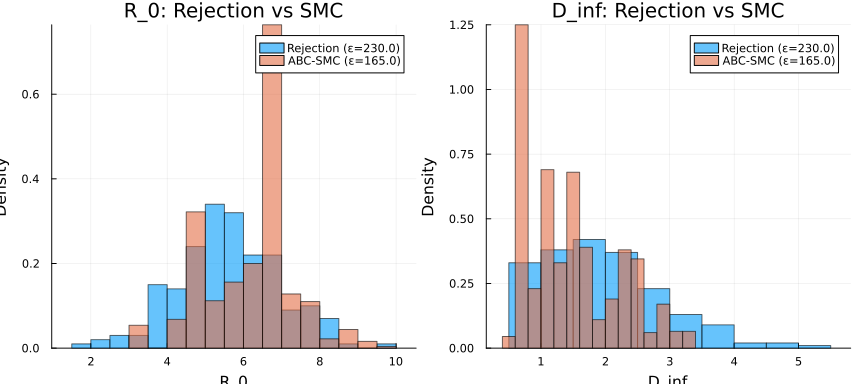

```julia
# Visual comparison
p1 = histogram(abc_df.R_0, bins=20, alpha=0.6, normalize=:pdf,
               label="Rejection (ε=$threshold)", xlabel="R_0", ylabel="Density")
histogram!(p1, abc_smc_df.R_0, bins=20, alpha=0.6, normalize=:pdf,
           label="ABC-SMC (ε=$(thresholds[end]))")

p2 = histogram(abc_df.D_inf, bins=20, alpha=0.6, normalize=:pdf,
               label="Rejection (ε=$threshold)", xlabel="D_inf", ylabel="Density")
histogram!(p2, abc_smc_df.D_inf, bins=20, alpha=0.6, normalize=:pdf,
           label="ABC-SMC (ε=$(thresholds[end]))")

plot(p1, p2, layout=(1, 2), size=(900, 400),
     title=["R_0: Rejection vs SMC" "D_inf: Rejection vs SMC"])
```

The two totals printed above answer different questions: the rejection run stops at 230, and ABC-SMC goes on to 165. The figure below shows why that gap decides the comparison. It samples parameter sets from the prior, simulates each one, and plots the fraction landing under each threshold.

**Plotting code**

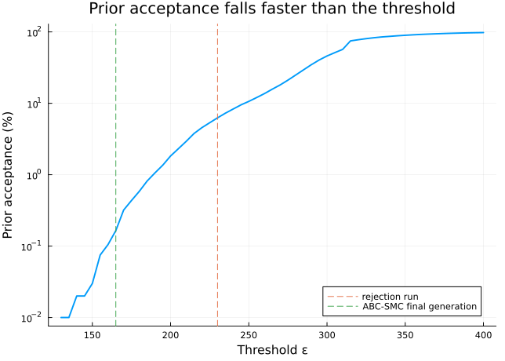

```julia
prior_draws = [distance_L1(simulate_abc(sample_from_prior()), observed_data)
               for _ in 1:20_000]
grid = 130:5:400
acceptance = [mean(prior_draws .< ε) for ε in grid]

plot(grid, 100 .* max.(acceptance, 1e-4), yscale = :log10,
     xlabel = "Threshold ε", ylabel = "Prior acceptance (%)",
     label = "", linewidth = 2,
     title = "Prior acceptance falls faster than the threshold")
vline!([230.0], label = "rejection run", linestyle = :dash)
vline!([165.0], label = "ABC-SMC final generation", linestyle = :dash)
```

Acceptance falls away far faster than the threshold does, so the cell below turns the curve into the two numbers that matter: how many simulations each method spends per effective sample at the threshold ABC-SMC reaches.

```julia
ε_final = thresholds[end]
prior_acceptance = mean(prior_draws .< ε_final)

## Rejection draws are unweighted, so its effective sample size is its draw count
rejection_per_ess = 1 / prior_acceptance

## The ABC-SMC particles are weighted, and the earlier generations cannot be
## skipped, so the whole total counts against the final generation's ESS
smc_per_ess = sum(abc_smc_sims) / abc_smc_ess[end]

println("At ε = ", ε_final, ", simulations per effective sample")
println("  rejection sampling: ", round(Int, rejection_per_ess),
        "  (prior acceptance ", round(100 * prior_acceptance, digits = 2), "%)")
println("  ABC-SMC:            ", round(Int, smc_per_ess),
        "  (", sum(abc_smc_sims), " simulations, final ESS ",
        round(abc_smc_ess[end], digits = 1), ")")
```

```
At ε = 165.0, simulations per effective sample
  rejection sampling: 606  (prior acceptance 0.16%)
  ABC-SMC:            369  (5147 simulations, final ESS 14.0)
```

ABC-SMC comes out ahead at this threshold, and further ahead on raw draws, where rejection sampling would need in the order of 100,000 simulations for 200 of them. The factor moves between runs, so take the ordering and the reason for it: ABC-SMC concentrates its effort where the data are without being told where that is, and that wins whenever prior acceptance at the threshold you want is small. At 230 it is not small, and rejection sampling is the better tool there.

The effective sample size printed for each generation measures a second problem. It starts at all 100 particles, which are drawn from the prior and weighted equally, and then drops. That is weight degeneracy, and it thins out the sample the final plots are drawn from:

```julia
println("distinct parameter vectors behind the resampled sample: ",
        length(unique(eachrow(abc_smc_df))), " of ", nrow(abc_smc_df), " draws")
```

```
distinct parameter vectors behind the resampled sample: 99 of 1000 draws
```

Part of the apparent sharpness in those plots is duplication. Our sampler draws parents in proportion to weight, which spreads the next generation over the particles that hold it, but it never resets the weights when the effective sample size falls, and it never adapts the kernel width. Production implementations do both. Treat the final spread as indicative and do not report it as a posterior.

**ImportantAssessing ABC posterior quality**

Rejection ABC does not produce chains, so chain diagnostics like R-hat have nothing to work with. ABC-SMC produces weights, and the effective sample size of those weights tracks the same problem, as above. Beyond that, assess ABC posterior quality by:

- **Acceptance rate**: Very low rates (< 0.1%) suggest the threshold is too strict or the model is a poor fit. Very high rates (> 10%) suggest the threshold is too loose and the posterior is close to the prior.
- **Visual comparison with likelihood-based posteriors**: When a likelihood is available (as in this session), run both methods and compare. Large discrepancies suggest either the ABC threshold is too loose or the distance metric captures different features than the likelihood.
- **Threshold sensitivity**: Run ABC with several thresholds. If the posterior changes substantially as you tighten the threshold, it has not yet converged, and you need a stricter threshold and more computation.
- **Coverage of prior**: If the ABC posterior looks very similar to the prior, the threshold is too loose and the data are not informing the inference.
- **Replicate runs**: Run ABC multiple times with different random seeds. If posteriors differ substantially between runs, you need more particles or a less strict threshold.

# Do they give similar results?

The ABC posterior below is the rejection sample from the start of this session, 200 draws at a threshold of 230 under the L1 distance. The ABC-SMC particles reach 165 and are weighted, which makes them harder to put in a histogram beside an unweighted chain, so they are left out of this comparison.

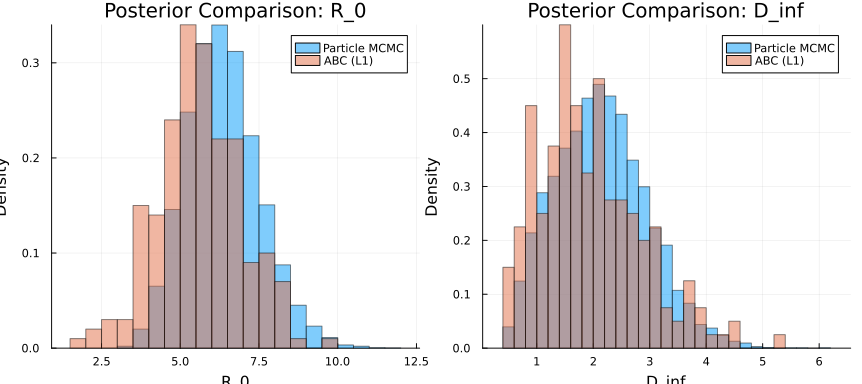

```julia
# Extract MCMC results
mcmc_df = pmcmc_chain

# Plot comparison
p1 = histogram(mcmc_df.R_0, bins=30, alpha=0.5,
               label="Particle MCMC", normalize=:pdf)
histogram!(p1, abc_df.R_0, bins=30, alpha=0.5,
           label="ABC (L1)", normalize=:pdf,
           xlabel="R_0", ylabel="Density",
           title="Posterior Comparison: R_0")

p2 = histogram(mcmc_df.D_inf, bins=30, alpha=0.5,
               label="Particle MCMC", normalize=:pdf)
histogram!(p2, abc_df.D_inf, bins=30, alpha=0.5,
           label="ABC (L1)", normalize=:pdf,
           xlabel="D_inf", ylabel="Density",
           title="Posterior Comparison: D_inf")

plot(p1, p2, layout=(1, 2), size=(900, 400))
```

The exercise below asks about the ratio $R_0 / D_\mathrm{inf}$, so here are the marginals, that ratio, and the correlation behind it.

```julia
for (name, df) in (("particle MCMC", mcmc_df), ("ABC (L1)", abc_df))
    ratio = df.R_0 ./ df.D_inf
    println(rpad(name, 14),
            " R_0 ", round(mean(df.R_0), digits = 2),
            ", D_inf ", round(mean(df.D_inf), digits = 2),
            ", ρ ", round(mean(df.ρ), digits = 2),
            ", R_0/D_inf ", round(mean(ratio), digits = 2),
            " (", round(quantile(ratio, 0.05), digits = 2), " to ",
            round(quantile(ratio, 0.95), digits = 2), ")",
            ", cor(R_0, D_inf) ", round(cor(df.R_0, df.D_inf), digits = 2))
end
```

```
particle MCMC  R_0 6.36, D_inf 2.14, ρ 0.69, R_0/D_inf 3.46 (1.75 to 6.8), cor(R_0, D_inf) 0.28
ABC (L1)       R_0 5.6, D_inf 1.95, ρ 0.57, R_0/D_inf 3.41 (1.68 to 6.53), cor(R_0, D_inf) 0.54
```

**TipExercise: Where do the two disagree, and why?**

1. Which parameter do the two posteriors agree on most closely? Which least?
2. Look at $R_0 / D_\mathrm{inf}$ printed above for both. How does the agreement there compare with the agreement on the marginals?
3. Why might these data pin down that combination better than either parameter on its own?

**TipSolution**

ABC comes out lower on all three marginals, and by the most on $\rho$: about 0.57 against the particle filter’s 0.69. $R_0$ is next, near 5.6 against 6.4, and $D_\mathrm{inf}$ is the closest of the three at 1.95 against 2.14. Measured against how wide these posteriors are, none of the three disagreements is large.

The ratio tells a different story from the marginals. $R_0/D_\mathrm{inf}$ comes out at 3.41 from ABC and 3.46 from particle MCMC, with 90% intervals that lie almost on top of each other. The two methods agree about the ratio to within a couple of per cent while differing on both of the parameters that make it up.

That is not an accident of this run. $R_0/D_\mathrm{inf}$ is the transmission rate $\beta$, and daily case counts constrain the speed and size of the epidemic, which depend on $\beta$. Separating $R_0$ from $D_\mathrm{inf}$ needs information about how long people stay infectious, and a count of cases per day carries very little of that. So the posterior is stretched along a ridge where the ratio is fixed and the two parameters trade off against each other. You can see it in the correlation between them: $+0.54$ in the ABC sample against $+0.28$ in the particle MCMC one, so ABC is lying along that ridge more tightly.

A posterior can be right about what the data determine and still look wrong parameter by parameter. Marginal histograms hide that, because they show each parameter with the others integrated away. Plot the pairs before concluding that two methods disagree.

# Learning points

**TipLearning points**

- ABC replaces the likelihood with an explicit distance, but choosing L1 over L2 over a weighted distance is the same kind of choice as picking Poisson over negative binomial
- The acceptance threshold is the hard part: too tight and nothing is accepted, too loose and you are sampling the prior
- ABC-SMC walks the threshold down in stages, concentrating effort where the data are without being told where that is, with weights that become uneven. It wins where prior acceptance at the threshold you want is small, and earns nothing at a loose threshold the prior already reaches
- Comparing a summary instead of the whole series is the concession you cannot undo. A tighter threshold recovers what the tolerance gave up; nothing recovers what the summary discarded
- The particle filter fits this model better than ABC does. ABC earns its place where the filter cannot run: no observation density to weight with, or a simulator you cannot stop and restart

# Going further

## ABC-MCMC

The callout earlier in this session defines `abc_mcmc`. Run it down a ladder of thresholds, and then sweep the proposal width at the loosest and the tightest, reporting the effective sample size of the $R_0$ draws alongside the acceptance rate.

**TipExercise: why tuning will not save this**

In the MCMC session a low acceptance rate meant the proposal was too wide, and you fixed it by tuning `proposal_sd`. Predict what the sweep will show at ε = 230 and at ε = 165 before you run the cells, then explain the difference between the two columns.

```julia
start_distances = [distance_L1(simulate_abc(θ), observed_data) for θ in abc_samples]
θ_start = abc_samples[argmin(start_distances)]

"Effective sample size of the R_0 draws in an ABC-MCMC chain."
ess_R_0(chain) = ess(reshape([θ[1] for θ in chain], :, 1)) ## draws by chains

for ε in (230.0, 200.0, 180.0, 165.0)
    chain, acceptance = abc_mcmc(θ_start, simulate_abc, distance_L1,
                                 observed_data, ε, 4000)
    println("ε = ", ε,
            ": acceptance ", lpad(round(100 * acceptance, digits = 1), 5),
            "%, ESS ", lpad(round(Int, ess_R_0(chain)), 3), " from 4000 draws")
end
```

```
ε = 230.0: acceptance  38.3%, ESS  30 from 4000 draws
ε = 200.0: acceptance  20.0%, ESS  11 from 4000 draws
ε = 180.0: acceptance   9.8%, ESS  12 from 4000 draws
ε = 165.0: acceptance   3.9%, ESS  11 from 4000 draws
```

```julia
for scale in (0.25, 1.0, 2.5, 5.0)
    proposal_sd = scale .* [0.4, 0.3, 0.05]
    for ε in (230.0, 165.0)
        chain, acceptance = abc_mcmc(θ_start, simulate_abc, distance_L1,
                                     observed_data, ε, 4000;
                                     proposal_sd = proposal_sd)
        println("proposal × ", lpad(scale, 4), ", ε = ", ε,
                ": acceptance ", lpad(round(100 * acceptance, digits = 1), 5),
                "%, ESS ", lpad(round(Int, ess_R_0(chain)), 3))
    end
end
```

```
proposal × 0.25, ε = 230.0: acceptance  51.6%, ESS  12
proposal × 0.25, ε = 165.0: acceptance   4.7%, ESS   9
proposal ×  1.0, ε = 230.0: acceptance  33.0%, ESS  13
proposal ×  1.0, ε = 165.0: acceptance   4.4%, ESS  12
proposal ×  2.5, ε = 230.0: acceptance  21.0%, ESS  92
proposal ×  2.5, ε = 165.0: acceptance   2.2%, ESS  14
proposal ×  5.0, ε = 230.0: acceptance   9.4%, ESS  76
proposal ×  5.0, ε = 165.0: acceptance   0.6%, ESS  11
```

At ε = 230 the effective sample size rises as the proposal widens and then falls again once too little is accepted, so there is an optimum you can find. At ε = 165 there is nothing to find: the acceptance rate falls and the effective sample size sits at about a dozen out of four thousand whatever you set.

## Summary statistics for ABC

ABC often works better on carefully chosen summary statistics than on full time series. For epidemic data, useful summaries include:

- **Total cases**: Sum of all observations
- **Peak timing**: Day with maximum incidence
- **Peak height**: Maximum daily incidence
- **Growth rate**: Initial doubling time or exponential growth rate
- **Final size**: Cumulative attack rate

Here is an example of how to define and use summary statistics for ABC:

```julia
"""Extract summary statistics from an epidemic time series."""
function epidemic_summaries(data)
    return [
        sum(data),                          # Total cases
        argmax(data),                       # Peak timing (day index)
        maximum(data),                      # Peak height
        sum(data[1:min(5, length(data))])   # Early cumulative cases (proxy for growth rate)
    ]
end

# Distance on summaries rather than full time series
function distance_summaries(sim, obs)
    s_sim = epidemic_summaries(sim)
    s_obs = epidemic_summaries(obs)
    # Normalise each summary by the observed value to make them comparable
    return sum(abs.(s_sim .- s_obs) ./ (abs.(s_obs) .+ 1.0))
end
```

Fewer, well-chosen summaries make ABC more robust to noise and model misspecification. Summaries that discard too much information produce wider posteriors. Which summaries to use is problem-specific, and finding out takes experimentation.

Try passing `distance_summaries` to `abc_rejection` in place of `distance_L1` and compare the posteriors you get. The four summaries throw away the day-to-day shape of the curve, so expect them to widen. How much each parameter widens tells you how much of what identified it lived in the detail of the trajectory, beyond the peak, total and timing.

## Robust distance metrics

For ABC with outliers or model misspecification, consider robust distances:

- **Median absolute deviation** in place of mean squared error
- **Quantile-based distances** that down-weight extreme values
- **Feature-based distances** that focus on epidemiologically meaningful patterns

Try replacing `distance_L1` in `abc_rejection` with a median-based version, `distance_median(sim, obs) = median(abs.(sim .- obs))`, and compare the posteriors. A robust distance stops a handful of large daily discrepancies dominating the fit, so how much the posterior moves tells you how much of it was being decided by a few days.

# References

- Marjoram, P. et al. (2003). [Markov chain Monte Carlo without likelihoods](https://doi.org/10.1073/pnas.0306899100). *PNAS* 100(26), 15324-15328. (ABC-MCMC)
- Toni, T. et al. (2009). [Approximate Bayesian computation scheme for parameter inference and model selection in dynamical systems](https://doi.org/10.1098/rsif.2008.0172). *J. R. Soc. Interface* 6(31), 187-202. (The ABC-SMC paper - highly readable introduction)
- Wood, S.N. (2010). [Statistical inference for noisy nonlinear ecological dynamic systems](https://doi.org/10.1038/nature09319). *Nature* 466, 1102-1104. (Synthetic likelihood approach)
- Marin, J.-M. et al. (2012). [Approximate Bayesian computational methods](https://doi.org/10.1007/s11222-011-9288-2). *Statistics and Computing* 22, 1167-1180.
- Cranmer, K. et al. (2020). [The frontier of simulation-based inference](https://doi.org/10.1073/pnas.1912789117). *PNAS* 117(48), 30055-30062. (Comprehensive review of modern likelihood-free methods)

# Next session

You have now met every family of method the course covers. Synthesis and next steps puts them side by side, asks which one your own problem needs, and points at the further topics that go beyond it.